# standview

Martin Ritchie, Pacific Southwest Research Station, Redding CA, USA

2024-06-25

## Introduction

The standview package is an R-package for rendering a high-resolution stand density management diagram (DMD). A stand density management diagram is a visual aid used by foresters to evaluate stands based on stem density (number of trees per unit area) and either a mean tree size such as quadratic mean diameter, or basal area per unit area. In standview, one of two different formats may be generated. The first format is a plot in Reineke-space (Reineke 1933) and is called with the dmd.view function: `dmd(ineq=i,...)`. The second option generates a figure in Gingrich-space (Gingrich 1967) and it is called with the gdmd.view function: `gdmd.view(ineq=i, ...)`.

The functions presented in standview use Imperial units as a default setting of the use.metric argument: use.metric=FALSE. When use.metric=TRUE, then the DMD will be rendered in metric units. Users should note that the change to metric units may come with an attendant change in other inputs as well. If ineq=1, 6, 10, 11, 12, 13, or 14 the user must specify a limiting sdi with the argument: max.sdi=*xxx*. Thus, care should be taken to assure that the limiting sdi and sdi lines are rendered in proper units (Imperial or metric) as dictated by the use.metric argument.

By default, stem density is trees acre<sup>-1</sup> and basal area is square feet acre<sup>-1</sup>. Also, by default, diameter is in inches, and was originally defined as the quadratic mean (the diameter of the tree of mean basal area in a stand). If the user is employing the summation method (Long and Daniel 1990) to calculate stand density index then it is important to recognize that the implied stand diameter is the generalized mean diameter (Zeide 1983), not the quadratic mean diameter. As such, the Gingrich-style DMD should not be selected with the summation method because iso-lines for generalized mean diameter cannot be rendered in a way that is consistent with the generalized mean diameter. That is to say that basal area cannot be derived from the generalized mean.

### Access

The package is not currently available from CRAN, but the latest version can be installed from the R console by pulling it from github in a two-step process. First, if the user does not have the devtools package installed, the install.packages function must be called with the argument “devtools”. Then the standview package may be installed with a call to the install_github function provided by devtools:

```r
install.packages("devtools")
library(devtools)
devtools::install_github("mwritchie/standview")
```

After installing the package in R, it must be loaded at runtime with the library function:

```r
library(standview)
```

The current version of standview is 1.0.0.

## Reineke-Space Density Management Diagrams

The dmd.view function will produce a Reineke-space diagram with the natural log of stem density on the x-axis and natural log of diameter on the y-axis. This will appear very similar to the figures produced in Reineke (1933) with the axes switched. Although there are 17 potential items in the argument list for this function, in most instances only a few will be needed as the default values will generally suffice. The most important argument is ineq; it specifies which species, or species group, is required. The ineq argument must be specified as an integer between 1 and 15 in the current version. The ineq value defines the inverse slope of the limiting sdi (most often reineke.term=1.605), the value for limiting sdi (max.sdi), as well as volume and dominant height estimation functions if appropriate. It is important to note that the default units are Imperial.

Table 1. Definitions of species and reference for DMD rendering by index of equations (ineq) in standview.

| ineq | Species | Reference |
| --- | --- | --- |
| 1 | User Defined | None |
| 2 | ponderosa pine | Long and Shaw (2005) |
| 3 | ponderosa pine | Jang et al. (2021) |
| 4 | ponderosa pine | Edminster (1988) |
| 5 | ponderosa pine | Cochran and Barrett (1992) |
| 6 | California mixed-conifer | Long and Shaw (2012) |
| 7 | Douglas-fir | Long et al. (1988) |
| 8 | White fir | Zhang et al. (2007) |
| 9 | Lodgepole pine | McCarter and Long (1986) |
| 10 | spruce-fir | Weiskittel and Woodall (2023) |
| 11 | red spruce | Weiskittel and Woodall (2023) |
| 12 | balsam fir | Weiskittel and Woodall (2023) |
| 13 | redwood/Douglas-fir | Ritchie and Berrill (2022) |
| 14 | Douglas-fir/redwood | Ritchie and Berrill (2022) |
| 15 | loblolly pine | Williams (1994) |

Note that volume estimation in Reineke-space has traditionally often presented as a series of iso-volume lines which the user then employs to visually approximate the volume estimate. This imprecise analog approach is no longer necessary. In R, these volumes estimates can be maintained, with greater precision, in a data frame. Nonetheless, dmd.view will draw iso-volume lines if the user specifies invol=TRUE in the argument list (see section on dmd.volume below). The dmd.view function is set up to render well in a 6wx8h canvas. For this reason opening a pdf is recommended: pdf(“mydmdfile.pdf”, width=6, height=8).

### Generic DMD in Reineke Space: ineq=1

When ineq=1, dmd.view will produce a user-specified density management diagram. As such the user will need to specify the upper limit for stand density index (max.sdi), a title (dmd.title), the intermediate sdi lines (sdi.lines), the management zone (mgt.zone), the inverse slope of the limiting sdi (reineke.term) if it is other than 1.605. When using ineq=1, the user needs to be mindful of the units. For example, when use.metric=TRUE, the max.sdi is trees ha <sup>-1</sup>, whereas when use.metric=FALSE max.sdi must be specified in trees ac <sup>-1</sup>.

### Published DMD in Reineke Space: ineq=(2-15).

In general, the user should be able to render a DMD using a published source with a fairly sparse argument list, by relying on the default arguments. The example below uses ineq=9 to render a lodgepole pine DMD (McCarter and Long 1986).

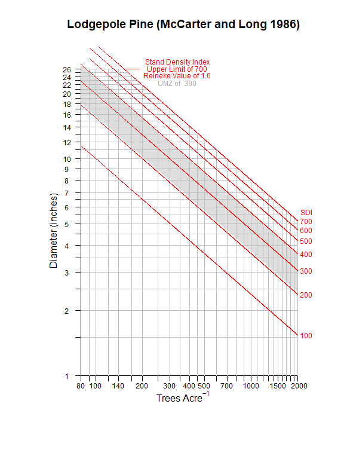

```r
dmd.view(ineq=9, insdr=TRUE)
```

In this particular example the insdr argument is set to true for SDI limits placed on right side of the figure. Although standview has default values provided for sdi.lines for all ineq>1, the user can over-ride these defaults. The recommended length for sdi.lines is no more than six and they must all be less than the sdi.max value.

## Gingrich Space Density Management Diagrams

Diagrams in Gingrich space use the same range of values for ineq (Table 1) as the Reineke format. Traditionally these figures do not present volume or dominant height information so there is no volume argument (invol) or volume color argument (vcol). An example Gingrich DMD using ineq=4 (Edminster 1988):

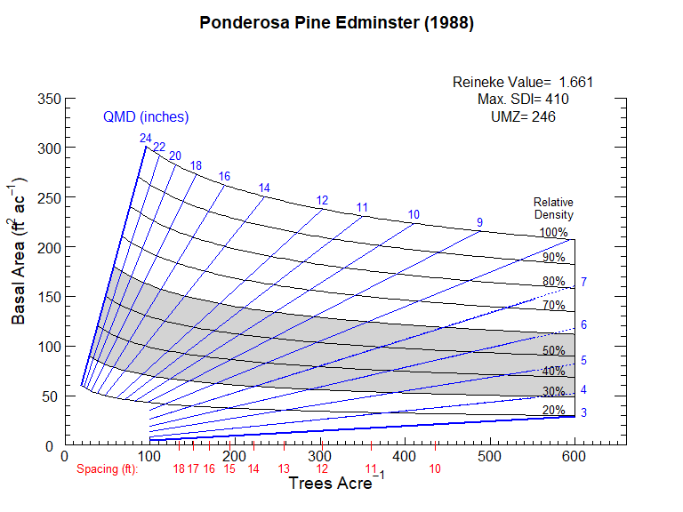

```r
opar <- par(mar = c(3.0,2.0,2.5,2.5))
gdmd.view(ineq=4)
```

```r
par(opar)
```

The gdmd.view function is set up to render well in a 8wx6h canvas. For this reason opening a pdf is recommended: pdf(“mydmdfile.pdf”, width=8, height=6). Note that as with Reineke space, some ineq values will require a user-specified sdi.max value.

## Data Overlay

Of course a DMD with no data is fairly useless. One could plot data by hand, but that would be clunky. One may wish to overlay data from sampled stands or from growth model projections over time. This may be accomplished using functionality provided by R. Some functions you may find useful in plotting data and annotating figures are: `points()`, `lines()`, `segments()`, `text()`. The standview package comes with a sample data frame from the Goosenest Adaptive Management Area on the Klamath National Forest (Ritchie 2005) called gama05. The example below shows sampled treated plots (controls excluded) overlay with a Gingrich-style DMD using the gama05 data.

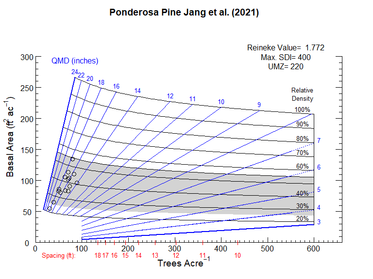

```r
opar <- par(mar = c(3.0,2.0,2.5,2.5))
gdmd.view(ineq=3)
points(x=gama05[!gama05$treatment=="Control",]$tpa,
       y=gama05[!gama05$treatment=="Control",]$ba,
       cex=1.25, pch=21, col="black")
```

```r
par(opar)
```

## Volume and Dominant Height

Often, a Reineke-space DMD will have iso-volume and/or iso-height lines. Below is an example of a Douglas-fir DMD with iso-volume lines.

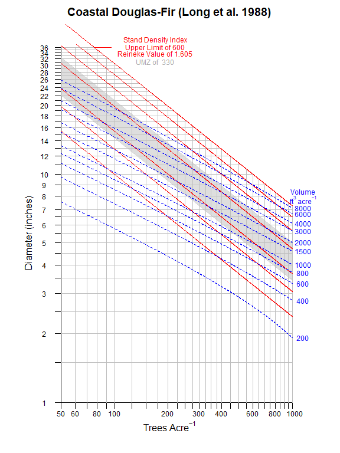

```r
opar <- par(mar = c(2.0, 2.0, 2.0, 2.0))

dmd.view(ineq=7, insdr=FALSE, invol=TRUE)
```

```r
par(opar)
```

However, in the R environment these are vestigial items. A better way of determining volume is to calculate the volume and dominant height for any particular data point with precision rather than visually estimating the value. The standview package allows for this with the dmd.volume function: `dmd.volume(ineq=i,...)`.

```r
DF<-dmd.volume(ineq=3,
               qmd=gama05$qmd,
               tpa=gama05$tpa,
               use.metric=FALSE) # generate volume and dom. ht.

DF
```

```
#>     tpa.ac  qmd.in ba.ft2ac volume.ft3ac vol.se.ft3ac height.ft height.se.ft biomass.Tonsac biomass.se.Tonsac    ccpct  ccpct.se
#> 1   63.056 17.5130 105.4812     3037.393     22.79861  92.87972    0.5714971       50.48924        0.06569949 33.43964 0.1517091
#> 2   73.889 14.9996  90.6706     2278.034     21.36697  80.42310    0.5592758       40.36247        0.06327103 32.10796 0.1403479
#> 3   50.278 17.7207  86.1127     2405.099     22.34488  89.26077    0.6030349       41.38380        0.06518281 28.44368 0.1613989
#> 4  715.000  6.8884 185.0419     2651.114     56.48172  56.10510    1.0965300       57.02820        0.18989221 69.51478 0.3105586
#> 5   70.263 17.2136 113.5527     3272.869     22.75995  93.39205    0.5611058       53.94463        0.06633345 35.62326 0.1474458
#> 6   79.474 17.6042 134.3337     4048.742     23.31335  98.67923    0.5686132       64.54131        0.07087685 39.84585 0.1530283
#> 7   72.500 16.2334 104.2040     2837.713     22.22259  87.86974    0.5554570       48.15414        0.06476621 34.34811 0.1416834
#> 8   49.412 17.5382  82.8953     2282.034     22.11933  87.83492    0.6095903       39.63707        0.06489141 27.74720 0.1620209
#> 9   83.333 15.5825 110.3618     2945.485     21.77439  86.55412    0.5327254       50.05436        0.06464094 36.53610 0.1341814
#> 10 585.000  7.6760 187.9980     2972.368     53.72142  60.58937    1.0310119       61.02157        0.16990069 67.74007 0.2870059
#> 11  70.000 16.3437 101.9826     2780.322     22.26215  87.83832    0.5608041       47.27007        0.06467202 33.68876 0.1435159
#> 12  53.611 16.6026  80.5997     2127.462     21.61659  84.01164    0.6079298       37.57359        0.06352249 27.88940 0.1580378
#> 13  39.167 17.4449  65.0107     1694.706     20.84455  82.58176    0.6811485       30.94376        0.06537807 22.89577 0.1711547
#> 14  88.897 14.1271  96.7655     2351.852     20.77038  78.25591    0.5197025       41.90553        0.06282241 34.69887 0.1297936
#> 15  70.278 14.7308  83.1763     2032.466     20.95859  77.79346    0.5748924       36.70011        0.06258796 30.31482 0.1449708
#> 16 714.167  7.0979 196.2397     2902.026     62.32640  58.25127    1.1429029       61.34497        0.20483144 70.85342 0.3137319
#> 17  30.278 18.2517  55.0125     1416.850     20.83250  81.70660    0.8304236       26.67851        0.07098050 19.48677 0.1762949
#> 18 737.059  7.3297 215.9743     3312.752     74.14752  61.25231    1.2440817       68.54521        0.23720786 73.35748 0.3226907
#> 19  64.412 15.4244  83.5816     2111.685     21.32479  80.47013    0.5862428       37.67332        0.06293765 29.75292 0.1488031
#> 20 676.199  8.7899 284.9507     5263.232    118.13135  75.06123    1.5916926       98.59667        0.33514607 78.53566 0.3333027
```

This function only works for those diagrams which provide volume estimates (ineq=2, 3, 6, 7, 9, 15).

Note that by default, dmd.volume produces estimates in Imperial units. For metric units, the argument list must include `use.metric=TRUE`.

## File Formats

Figures can be rendered in r a number of different formats. The pdf function works very well for producing publication quality images (`pdf("myDMD.pdf", ...)`). My general practice is to generate a pdf, and then convert to a .jpg file if needed for a particular outlet. Other graphics options are bmp (`bmp(filename = "myDMD.bmp", ...)`), jpeg (`jpeg(filename = "myDMD.jpeg", ...)`), png (`png(filename = "myDMD.png",...)`) and tiff ( `tiff(filename = "myDMD.tiff",...")`). It is important that any of these should be closed with a call to `dev.off()` after rendering the plot. Examples of usage with pdf are shown in the standview help files.

## References

Cochran, P.H., and J.W. Barrett (1992) Stocking levels and underlying assumptions for uneven-aged ponderosa pine stands. Res. Note PNW-509. USDA For. Serv. Pac. Northwest For. and Range Exp. Stn. 10p.

Gingrich, S. (1967) Measuring and evaluating stocking and stand density in upland hardwood forests in the central states. For. Sci. 13(1):38-53.

Jang, W.S., M.W. Ritchie, and J. Zhang (2021) Improved equations for the density management diagram isolines of ponderosa pine stands. For. Sci. 67(1):93-102.

Long, J.N., and T.W. Daniel (1990) Assessment of growing stock in uneven-aged stands. West. J. Appl. For. 5:93-96

Long, J.N., J.B. McCarter, and S.B. Jack (1988) A modified density management diagram for coastal Douglas-fir. West. J. Appl. For. 3(3):88-89.

Long, J.N., and J.D. Shaw (2005) A density management diagram for even-aged ponderosa pine stands. West. J. Appl. For. 20(4):205-215.

Long, J.N., and J.D. Shaw (2012) A density management diagram for even-aged Sierra Nevada mixed-conifer stands. West. J. Appl. For. 27(4):187-195.

McCarter, J.D., and J.N. Long (1986) A lodgepole pine density management diagram. West. J. Appl. For 1:6-11.

Reineke, L.H. (1933) Perfecting a stand density index for even-aged forests. J. Ag. Res. 46:627-638.

Ritchie, M.W. (2005) Ecological research at the Goosenest Adaptive Management Area in northeastern California. Gen. Tech. Rep. PSW-GTR-192. USDA For. Serv. Pac. SW Res. Stn. 120 p.

Ritchie, M.W. and J.-P. Berrill (2022) Precommercial thinning in California Forests. In: Stewart, W. (editor) Reforestation practices for conifers in California. Davis CA: University of California, Agriculture and Natural Resources.

Weiskittel, A. & Woodall, C. (2023) Stand density index and relative density calculator for the United States. figshare. Software. https://doi.org/10.6084/m9.figshare.24412246.v1

Williams, R.A. (1994) Stand density management diagram for loblolly pine plantations in north Louisiana. Southern Journal of Applied Forestry 18(1):40-45.

Zeide, B. (1983). The mean diameter for stand density index. Can. J. For. Res. 13:1023-1024.

Zhang, J., W.W. Oliver, and M.W. Ritchie (2007) Effect of stand densities on stand dynamics in white fir (*Abies concolor*) forests in northeast California, USA. For. Ecol. and Manage. 244:50-59.